# 《R + Amos + SPSS》

王超

20-09-2026

# 1 相关与回归(Cor. & Reg.)

## 1.1 双变量相关与偏相关

- 【参考文献】
  - 巢旭.社会支持与限制变通对科技体育爱好者深度休闲的影响研究[D].上海体育学院,2023.DOI:10.27315/d.cnki.gstyx.2023.000013.(P115)

[Correlation](https://www.statology.org/understanding-correlation-and-causation/)

In simple terms, correlation is the **strength and direction** of a (linear) relationship between two variables X and Y. It is a statistical measure that indicates how the two variables are related to each other, that is, correlated.

[partial correlation](https://www.statology.org/partial-correlation-r/)

In statistics, we often use the Pearson correlation coefficient to measure the linear relationship between two variables.

However, sometimes we’re interested in understanding the relationship between two variables while controlling for a third variable.

For example, suppose we want to measure the association between the number of hours a student studies and the final exam score they receive, while controlling for the student’s current grade in the class.

In this case, we could use a partial correlation to measure the relationship between hours studied and final exam score.

- 相关关系与函数关系
- 判定两个变量之间的相关关系
  1. 判断是否存在相关关系:散点图
  2. 相关关系的类别
  3. 计算相关关系的强弱——相关系数
     - $r = \frac{ \Sigma (x - \overline{x} )(y - \overline{y} )}{\sqrt{ \Sigma (x - \overline{x} )^{2} \Sigma (y - \overline{y} )^{2} }}$
     - |r| < 0.3:弱相关
     - 0.3 ≤ |r| < 0.5:低度相关
     - 0.5 ≤ |r| < 0.8:中度相关
     - 0.8 ≤ |r|:强相关
  4. 判断相关方向
     - r > 0 : 正相关
     - r < 0 : 负相关
  5. 检验相关关系是否具有统计学意义(相关关系是否可靠)
     - Sig < 0.05 : 相关关系可靠
     - Sig < 0.01 : 相关关系非常可靠
     - Sig > 0.05 : 相关关系不可靠
  6. **相关关系 != 因果关系**

【案例数据集】

【操作视频】

【结果呈现】

================================================================================

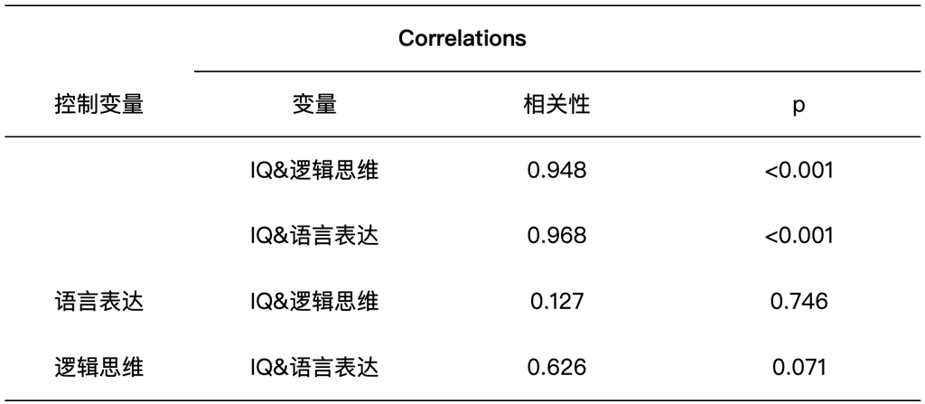

## 1.2 一元线性回归

- 【参考文献】
  - 刘嘉欣.中学体育教师职业认同与师德水平的关系研究[D].华东师范大学,2023.DOI:10.27149/d.cnki.ghdsu.2023.002027.(P69-72)

### 1.2.1 回归方程

- 一元线性方程

  $y = b_{0} + b_{1} x + \varepsilon$
- 一元线性回归方程
  - $\widehat{y} = b_{0} + b_{1} x$
  - $\widehat{y} = 6.5840 + 1.0713 x$
- 一元线性方程/回归方程相关说明
  - $\widehat{y} \ is\ the\ predicted\ value\ of \ the \ response\ variable.$
  - $b_{0} \ is\ the\ intercept \ of \ y.$
  - $b_{1} \ is \ the \ regression \ coefficient.$
  - $x \ is \ the \ value \ of \ the \ predictor \ variable.$
  - $\varepsilon\ \ is \ \ residuals.$

### 1.2.2 回归模型的前提(Assumptions of Linear Regression)

1. **Linear relationship**: There exists a linear relationship between the independent variable, x, and the dependent variable, y.
2. **Normality**: The residuals of the model are normally distributed.

### 1.2.3 回归模型的拟合

- **Finding the “Line of Best Fit”.**
- **Method of the Least Square.**

### 1.2.4 回归模型决定系数(The Coefficient of Determination)

- The way to measure **how well** the least squares regression line “fits” the data is using the coefficient of determination, denoted as $R^{2}$, range from 0 to 1.
- The coefficient of determination is the **proportion** of the variance in **the response** variable that can be **explained by the predictor variable**.
- $R^{2} = \frac{SSR}{SST}$
  - $SSR:Sum \ of \ Square \ of \ Regression;\ SSE:Sum \ Square \ of \ Error;\ SST: \ SSR+SSE.$

### 1.2.5 回归模型的检验(Test of Model of Linear Regression)

- Test of Linear Relationship.
  - Null Hypothesis:The Linear Relationship is Not Significant.
- Test of Regression Coefficient.
  - Null Hypothesis:The Coefficient is Significant 0.
- Test of Intercept.
  - Null Hypothesis:The Intercept is Significant 0.

### 1.2.6 回归模型的解读与预测、控制

- 预测(Predict)
- 控制(Control)
- **Caution**: Make sure you only use **values for the predictor variable** that are **within the range of the predictor variable in the original dataset** we used to generate the least squares regression line.

### 1.2.7 一元线性回归模型结果呈现

- ADM = 6.584 + 1.071 * CSR
  - CSR每增加一个单位，ADM平均增加1.071个单位；
  - (CSR每增加1个标准差，ADM平均增加0.916个标准差)；
  - 当CSR为0时，ADM为6.584.
  - 预测：当CSR为5时，ADM预测值（平均）为11.94；
  - 控制：ADM达到12以上，CSR至少应为5.057.

## 1.3 多元线性回归

### 1.3.1 Teaching Case: Simple-Mediation Model

- Analysis of Simple-Mediation Model Base on Regression & Process

## 1.4 二分类逻辑回归

**Logistic regression** is used for **predicting a binary outcome**, such as true and false or yes and no. It models the probability of the outcome class, such as true, as a function of the predictors. The relationship between the predictors and outcome is expressed as the log odds (logit) of the probability with the coefficients indicating the change in the log odds of the outcome for a one unit increase in that predictor.

- The required sample size is typically **15–50** times the number of predictors
- 【案例数据集:../Data/04Cor_Reg/二项Logistic-bankloan.sav】
- 变量筛选情况(以因变量为分类变量，筛选自变量差异显著项)
  - 连续型:平均数、标准差、t检验结果
  - 离散型:频数、百分比、卡方检验结果

- 模型构建
  - 回归方法：向前 LR
  - 指定分类变量参考值（二分类自变量(0,1)除外
  - 霍斯默-莱梅肖拟合优度检验（原假设：预测值与真实值之间无差异）
  - Exp(B)/OR置信区间（95%）

- 结果Exp(B)/OR的解读
  - 连续型:自变量每增1个单位，结局（因变量 = 1）的风险增加的倍数
  - 离散型:当前组发生结局（因变量 = 1）的风险相对于参照组的倍数
  - 二分类:赋值高（ = 1）的对象发生结局（因变量 = 1）的风险相对于赋值低（ = 0）的对象的倍数
- ROC曲线的绘制
  - 检验变量:预测值概率（模型构建过程需”保存”）
  - 状态变量:因变量，并设置状态值（1）
  - “显示”:“带对角参考线”、“标准误和置信区间”、“ROC曲线坐标点”
- ROC曲线解读
  - 曲线下面积参考值: > 0.8
  - 根据ROC曲线坐标的敏感度（覆盖率）选定临界值，调整回归选项中的”分类临界值”（SPSS默认为0.5）后，再进行回归拟合

## 1.5 多元逻辑回归

### 1.5.1 多元无序逻辑回归

【案例数据集:../Data/04Cor_Reg/多元无序逻辑回归.sav

- 模型: pres92 ~ gender + degree + age (因变量参考类别:2)
- 【因子】列入离散型自变量；【协变量】列入连续型自变量
- 【统计】:拟合优度

### 1.5.2 多元有序逻辑回归

【案例数据集:../Data/04Cor_Reg/多元有序逻辑回归.sav

- 模型: Y ~ X3 + X5
- 【输出】“平行线检验”(注：p > 0.05 )

- SPSS参数估算值结果的解读及应用
  - 阈值:[估算】为回归模型常数项
  - 位置:[估算]为自变量系数
  - OR = exp(“估算值”或”(LCI,UCI))